# Assignment 1: Case Study Report

2025-06-08

# Data

| **Variable** | **Description** |
| --- | --- |
| `respondent_id` | An identifier for our observations. |
| `variety_of_choice` | Importance of this attribute on a 1-10 scale. |
| `electronics` | Importance of this attribute on a 1-10 scale. |
| `furniture` | Importance of this attribute on a 1-10 scale. |
| `quality_of_service` | Importance of this attribute on a 1-10 scale. |
| `low_prices` | Importance of this attribute on a 1-10 scale. |
| `return_policy` | Importance of this attribute on a 1-10 scale. |
| `income` | Gross annual income expressed in thousands of USD. |
| `age` | Respondents’ age in years. |

## Libraries

```r
# Load required libraries
library(tidyverse)
library(dplyr)
library(tibble)
```

# 1. Customer Segmentation Analysis

### 1.1: Descriptive Analysis

```r
# Read the dataset
retailer <- read.csv("retailer.csv")

# View structure and summary
glimpse(retailer)
```

```
## Rows: 200
## Columns: 9
## $ respondent_id      <int> 1, 2, 3, 4, 5, 6, 7, 8, 9, 10, 11, 12, 13, 14, 15, …
## $ variety_of_choice  <int> 8, 6, 6, 8, 4, 8, 7, 7, 10, 8, 9, 4, 10, 6, 7, 9, 1…
## $ electronics        <int> 3, 3, 1, 3, 6, 4, 2, 5, 7, 4, 8, 4, 3, 5, 3, 1, 1, …
## $ furniture          <int> 6, 1, 2, 3, 3, 3, 2, 3, 5, 0, 2, 2, 6, 2, 0, 7, 7, …
## $ quality_of_service <int> 3, 4, 4, 4, 4, 5, 2, 2, 1, 4, 1, 8, 1, 4, 2, 4, 4, …
## $ low_prices         <int> 2, 7, 9, 8, 2, 10, 8, 2, 5, 9, 5, 2, 3, 3, 7, 5, 4,…
## $ return_policy      <int> 2, 1, 6, 7, 5, 6, 7, 3, 4, 1, 2, 3, 3, 6, 6, 2, 3, …
## $ income             <int> 16, 22, 18, 18, 35, 13, 22, 19, 14, 16, 82, 78, 17,…
## $ age                <int> 28, 27, 22, 29, 51, 24, 27, 26, 27, 28, 34, 49, 22,…
```

```r
summary(retailer)
```

```
##  respondent_id    variety_of_choice  electronics      furniture
##  Min.   :  1.00   Min.   : 4.000    Min.   : 1.00   Min.   :0.00
##  1st Qu.: 50.75   1st Qu.: 6.000    1st Qu.: 3.00   1st Qu.:1.00
##  Median :100.50   Median : 8.000    Median : 4.50   Median :2.00
##  Mean   :100.50   Mean   : 7.565    Mean   : 4.45   Mean   :3.27
##  3rd Qu.:150.25   3rd Qu.:10.000    3rd Qu.: 6.00   3rd Qu.:6.00
##  Max.   :200.00   Max.   :10.000    Max.   :10.00   Max.   :7.00
##  quality_of_service   low_prices     return_policy       income
##  Min.   :1.00       Min.   : 1.000   Min.   : 1.00   Min.   :13.00
##  1st Qu.:2.00       1st Qu.: 2.000   1st Qu.: 3.00   1st Qu.:15.00
##  Median :3.00       Median : 5.000   Median : 4.00   Median :19.50
##  Mean   :3.53       Mean   : 4.795   Mean   : 4.25   Mean   :32.17
##  3rd Qu.:4.00       3rd Qu.: 7.000   3rd Qu.: 6.00   3rd Qu.:54.25
##  Max.   :9.00       Max.   :10.000   Max.   :10.00   Max.   :95.00
##       age
##  Min.   :21.00
##  1st Qu.:24.00
##  Median :27.00
##  Mean   :32.52
##  3rd Qu.:38.00
##  Max.   :68.00
```

```r
# Generate descriptive statistics
desc_stats <- data.frame(
  Variable = names(retailer),
  Min = apply(retailer, 2, min),
  Max = apply(retailer, 2, max),
  Mean = round(apply(retailer, 2, mean), 2),
  SD = round(apply(retailer, 2, sd), 2)
)
desc_stats
```

```
##                              Variable Min Max   Mean    SD
## respondent_id           respondent_id   1 200 100.50 57.88
## variety_of_choice   variety_of_choice   4  10   7.57  2.01
## electronics               electronics   1  10   4.45  1.94
## furniture                   furniture   0   7   3.27  2.37
## quality_of_service quality_of_service   1   9   3.53  2.32
## low_prices                 low_prices   1  10   4.80  2.53
## return_policy           return_policy   1  10   4.25  2.05
## income                         income  13  95  32.17 22.70
## age                               age  21  68  32.52 11.88
```

An **abnormality** appears: **furniture** has a minimum of **0** even though the scale is 1–10, suggesting a data‐entry error or a special case that merits review before further analysis.

Wide SDs in **income** and **age** highlight demographic diversity that may also drive segmentation.

### 1.2: Min/Max in Normalised Dataset

```r
# Excluding respondent_id variables for normalization
store_attrs <- select(retailer, variety_of_choice, electronics, furniture,
                      quality_of_service, low_prices, return_policy, income, age)

# Z-score normalization
store_norm <- as.data.frame(scale(store_attrs))

# Find each variable’s minimum and maximum z‐score
norm_mins <- apply(store_norm, 2, min)
norm_maxs <- apply(store_norm, 2, max)

# Identify variable with smallest min and largest max
var_smallest_min <- names(which.min(norm_mins))
var_largest_max  <- names(which.max(norm_maxs))
var_smallest_min
```

```
## [1] "electronics"
```

```r
var_largest_max
```

```
## [1] "age"
```

While **electronics** ratings are highly polarized (most extreme low z-score), **age** has the most extreme high z-score, highlighting an outlier in the demographic variable. This informs us that both customer attitudes and demographics will meaningfully separate clusters.

### 1.3: Create and Normalize Clustering Data

```r
# Exclude respondent_id and select only the six store attributes
store_attrs <- select(retailer, variety_of_choice, electronics, furniture,
                      quality_of_service, low_prices, return_policy)

# Normalize and convert to tibble
store_norm <- as_tibble(scale(store_attrs))

# Display first rows
store_norm[1:3, ]
```

```
## # A tibble: 3 × 6
##   variety_of_choice electronics furniture quality_of_service low_prices
##               <dbl>       <dbl>     <dbl>              <dbl>      <dbl>
## 1             0.216      -0.746     1.15              -0.229     -1.10
## 2            -0.778      -0.746    -0.956              0.203      0.871
## 3            -0.778      -1.78     -0.535              0.203      1.66
## # ℹ 1 more variable: return_policy <dbl>
```

### 1.4: Distance Calculation

```r
# Compute Euclidean distances
distances <- dist(store_norm, method = "euclidean")

# Show distance matrix (first 5 rows and columns)
as.matrix(distances)[1:5, 1:5]
```

```
##          1        2        3        4        5
## 1 0.000000 3.122933 4.066279 3.654938 3.203876
## 2 3.122933 0.000000 2.795657 3.229408 3.434497
## 3 4.066279 2.795657 0.000000 1.618520 3.959120
## 4 3.654938 3.229408 1.618520 0.000000 3.593200
## 5 3.203876 3.434497 3.959120 3.593200 0.000000
```

- Respondents **1** and **2** have a distance of **3.12**, reflecting moderate dissimilarity in their profiles.
- Respondents **3** and **4** are very similar with a distance of **1.62**, indicating closely aligned preferences.
- Respondent **3** is also moderately similar to respondent **2** (distance **2.80**) but notably divergent from respondent **1** (distance **4.07**), the largest observed here.

These pairwise distances illustrate which customers cluster naturally—small distances group into tight segments, while large distances highlight outliers and drive key splits in the hierarchical tree.

### 1.5: Seed for Reproducibility

```r
# Set seed for reproducibility
set.seed(123)
```

By calling **set.seed(123)**, any random processes in later clustering steps will yield the same results each time the code is run. This ensures that cluster assignments remain consistent for grading and downstream analysis.

### 1.6: Hierarchical Clustering (Ward.D2)

```r
# Run hierarchical clustering
hier_clust <- hclust(distances, method = "ward.D2")

# View summary
hier_clust
```

```
##
## Call:
## hclust(d = distances, method = "ward.D2")
##
## Cluster method   : ward.D2
## Distance         : euclidean
## Number of objects: 200
```

This step creates a dendrogram structure grouping the 200 respondents (rows) based on their six normalized store-attribute ratings. This clustering structure will help us identify distinct customer segments based on those six attributes, pinpointing the heights at which natural groupings occur, guiding our choice of 3 or 4 clusters for segmentation.

### 1.7: Dendrogram Plot

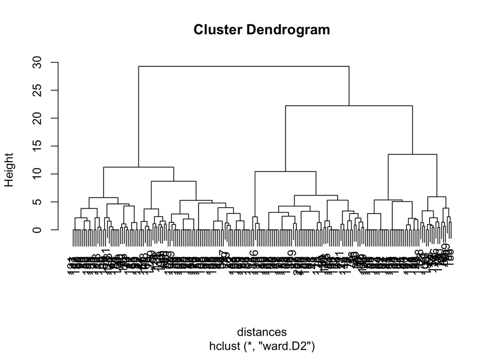

```r
# Plot dendrogram
plot(hier_clust)
```

The dendrogram visually displays how individuals merge into clusters at increasing levels of within-cluster variance

### 1.8: 3-Cluster Solution (Hierarchical)

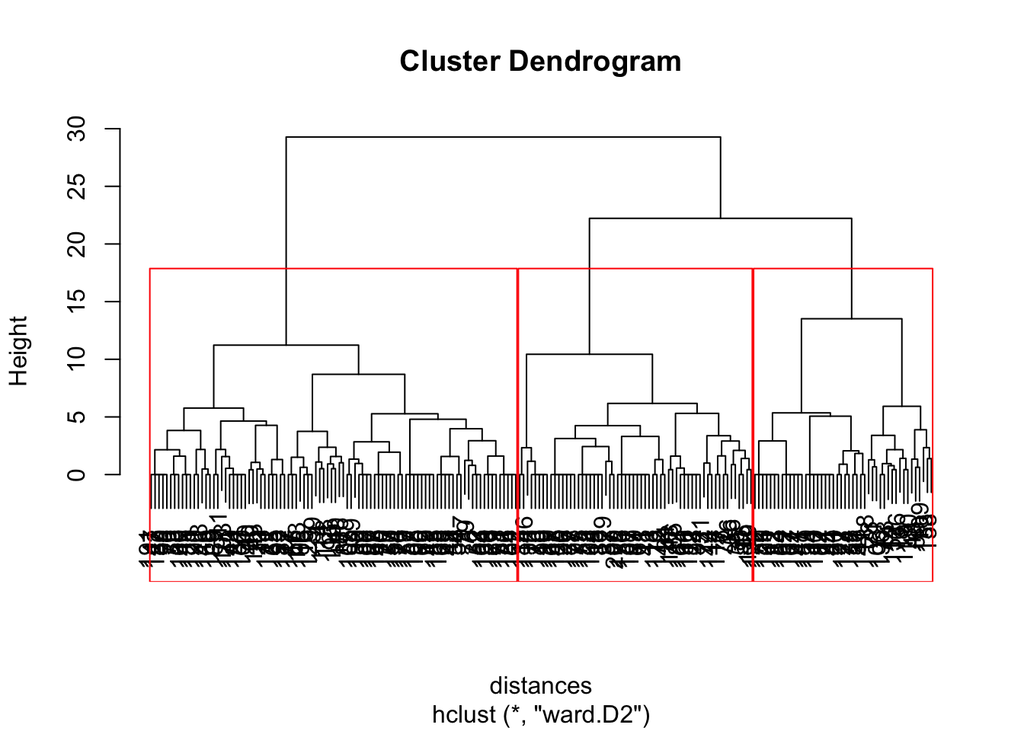

```r
# Plot and cut dendrogram
plot(hier_clust)
rect.hclust(hier_clust, k = 3, border = "red")
```

```r
# Assign 3 clusters
hc3 <- cutree(hier_clust, k = 3)
```

### 1.9: Cluster Sizes (3-Cluster)

```r
# Cluster sizes for 3-cluster solution
table(hc3)
```

```
## hc3
##  1  2  3
## 94 60 46
```

- **Cluster 1 (94 respondents)**: represents the dominant group, likely reflecting customers with moderate attitudes across multiple attributes.
- **Cluster 2 (60 respondents)**: a mid‐sized group that may emphasize one or two key attributes strongly.
- **Cluster 3 (46 respondents)**: the smallest group, potentially a niche with extreme preferences.

This 3‐cluster segmentation balances parsimony and interpretability, forming broadly actionable segments.

### 1.10: K-Means (3-Cluster)

```r
# Run k-means clustering
set.seed(123)
kmeans_clust3 <- kmeans(store_norm, centers = 3, iter.max = 1000, nstart = 100)

# View results
kmeans_clust3
```

```
## K-means clustering with 3 clusters of sizes 60, 46, 94
##
## Cluster means:
##   variety_of_choice electronics  furniture quality_of_service low_prices
## 1        -0.3223184  -0.7976158 -0.8719925         -0.2000189  1.3256625
## 2        -1.2319575   0.1487839 -0.6998284          1.3196743 -0.9583630
## 3         0.8086080   0.4363073  0.8990602         -0.5181264 -0.3771814
##   return_policy
## 1     0.7239225
## 2     0.2705426
## 3    -0.5944714
##
## Clustering vector:
##   [1] 3 1 1 1 2 1 1 3 3 1 3 2 3 2 1 3 3 1 3 2 2 3 1 2 3 3 3 2 1 3 1 3 3 3 1 1 1
##  [38] 2 3 3 1 3 2 2 3 1 2 3 3 3 2 3 3 3 1 1 1 2 3 3 1 3 2 2 3 1 2 3 3 3 2 1 3 1
##  [75] 3 3 1 1 3 3 1 3 2 3 2 1 3 3 1 3 2 2 3 1 1 1 3 3 1 3 2 3 2 1 3 3 1 3 2 2 3
## [112] 1 3 3 1 1 1 2 1 1 3 3 1 3 2 3 2 1 3 3 1 3 2 2 3 1 2 3 3 3 2 1 3 1 1 3 3 1
## [149] 3 2 3 2 1 3 3 1 3 2 2 3 1 2 3 3 3 2 1 3 3 1 3 2 3 2 1 3 3 1 3 2 2 3 1 2 3
## [186] 3 3 2 1 3 3 1 3 2 3 2 1 3 3 1
##
## Within cluster sum of squares by cluster:
## [1] 131.6906 167.9301 218.8121
##  (between_SS / total_SS =  56.6 %)
##
## Available components:
##
## [1] "cluster"      "centers"      "totss"        "withinss"     "tot.withinss"
## [6] "betweenss"    "size"         "iter"         "ifault"
```

```r
table(kmeans_clust3$cluster)
```

```
##
##  1  2  3
## 60 46 94
```

The centroids confirm:

- **Cluster 1** strongly values low_prices & return_policy
- **Cluster 2** values quality_of_service
- **Cluster 3** values variety & variety_of_choice

K-means optimizes within-cluster variance directly, providing complementary insight to the agglomerative approach.

### 1.11: 4-Cluster Solution (Hierarchical)

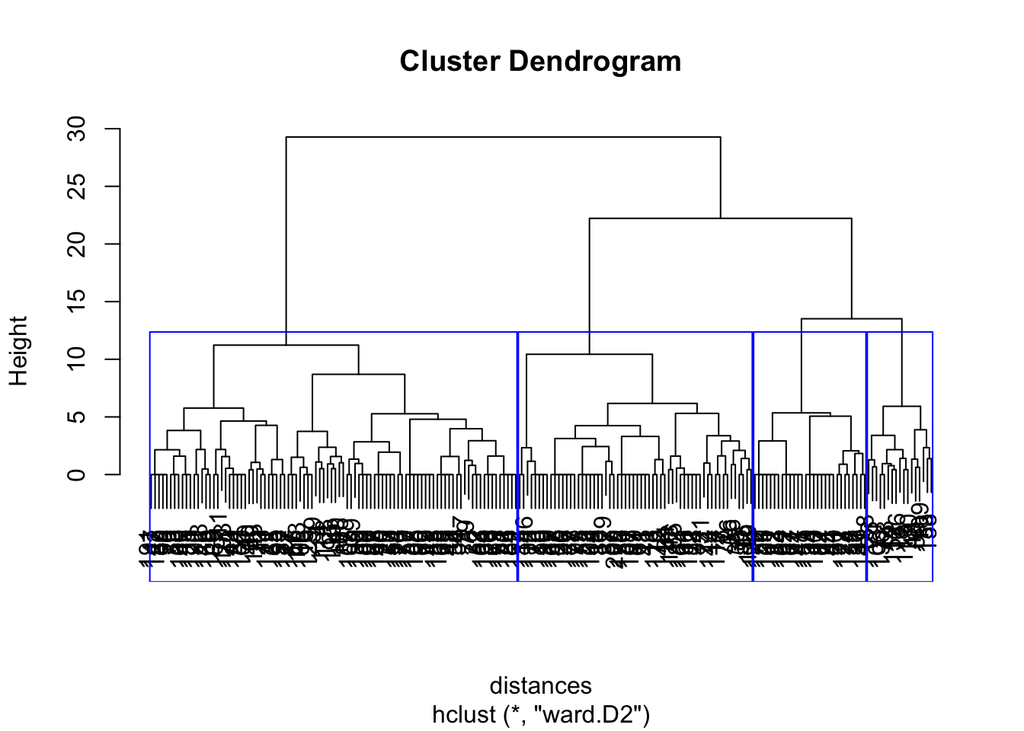

```r
# Plot and cut dendrogram for 4 clusters
plot(hier_clust)
rect.hclust(hier_clust, k = 4, border = "blue")
```

```r
# Assign 4 clusters
hc4 <- cutree(hier_clust, k = 4)
table(hc4)
```

```
## hc4
##  1  2  3  4
## 94 60 17 29
```

### 1.12: K-Means (4-Cluster)

```r
# Run k-means with 4 clusters
set.seed(123)
kmeans_clust4 <- kmeans(store_norm, centers = 4, iter.max = 1000, nstart = 100)

# View results
kmeans_clust4
```

```
## K-means clustering with 4 clusters of sizes 17, 60, 29, 94
##
## Cluster means:
##   variety_of_choice electronics  furniture quality_of_service low_prices
## 1        -1.3044319   1.0397762 -0.4854314         0.07592762 -0.8022309
## 2        -0.3223184  -0.7976158 -0.8719925        -0.20001891  1.3256625
## 3        -1.1894724  -0.3735220 -0.8255094         2.04876726 -1.0498887
## 4         0.8086080   0.4363073  0.8990602        -0.51812644 -0.3771814
##   return_policy
## 1     1.2559792
## 2     0.7239225
## 3    -0.3071271
## 4    -0.5944714
##
## Clustering vector:
##   [1] 4 2 2 2 1 2 2 4 4 2 4 3 4 1 2 4 4 2 4 3 3 4 2 3 4 4 4 1 2 4 2 4 4 4 2 2 2
##  [38] 3 4 4 2 4 1 3 4 2 3 4 4 4 3 4 4 4 2 2 2 3 4 4 2 4 1 3 4 2 3 4 4 4 1 2 4 2
##  [75] 4 4 2 2 4 4 2 4 3 4 1 2 4 4 2 4 3 3 4 2 2 2 4 4 2 4 3 4 1 2 4 4 2 4 1 3 4
## [112] 2 4 4 2 2 2 1 2 2 4 4 2 4 3 4 3 2 4 4 2 4 1 3 4 2 3 4 4 4 3 2 4 2 2 4 4 2
## [149] 4 3 4 1 2 4 4 2 4 1 3 4 2 3 4 4 4 1 2 4 4 2 4 3 4 3 2 4 4 2 4 1 3 4 2 3 4
## [186] 4 4 1 2 4 4 2 4 3 4 1 2 4 4 2
##
## Within cluster sum of squares by cluster:
## [1]  40.97896 131.69058  35.60665 218.81206
##  (between_SS / total_SS =  64.2 %)
##
## Available components:
##
## [1] "cluster"      "centers"      "totss"        "withinss"     "tot.withinss"
## [6] "betweenss"    "size"         "iter"         "ifault"
```

```r
table(kmeans_clust4$cluster)
```

```
##
##  1  2  3  4
## 17 60 29 94
```

The four clusters have sizes **17, 60, 29**, and **94**, showing a small niche, two mid‐sized groups, and one large segment.

- **Cluster 1** (17) is characterized by strong positive electronics (1.04) and return_policy (1.26) scores—an elite “**Tech & Returns**” niche.
- **Cluster 2** (60) aligns with high low_prices (1.33) and return_policy (0.72)—the “**Price‐Sensitive.**”
- **Cluster 3** (29) peaks on quality_of_service (2.05)—the small “**Service Lovers**.
- **Cluster 4** (94) shows the highest variety_of_choice (0.81) and furniture (0.90)—the broad “**Assortment Seekers**.”

### 1.13: Choosing Between 3 vs 4 Clusters (NbClust)

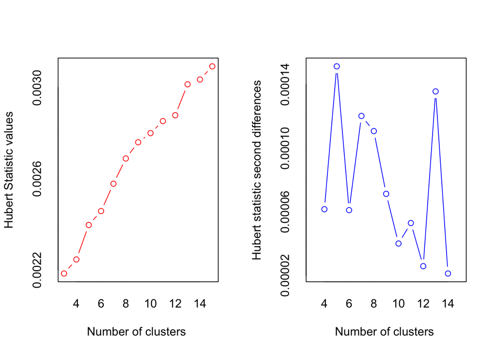

```
## *** : The Hubert index is a graphical method of determining the number of clusters.
##                 In the plot of Hubert index, we seek a significant knee that corresponds to a
##                 significant increase of the value of the measure i.e the significant peak in Hubert
##                 index second differences plot.
##
```

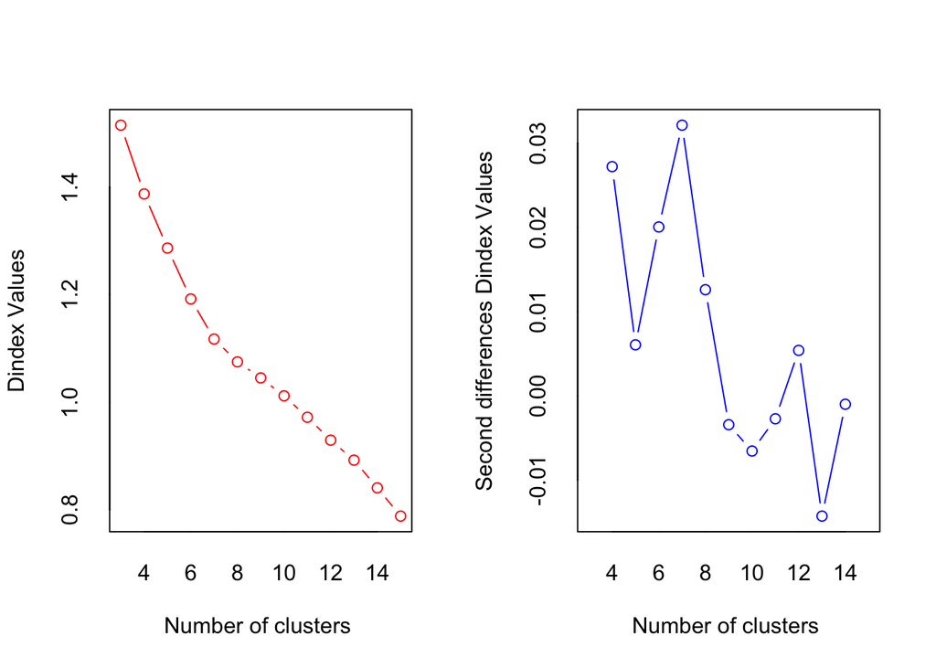

```
## *** : The D index is a graphical method of determining the number of clusters.
##                 In the plot of D index, we seek a significant knee (the significant peak in Dindex
##                 second differences plot) that corresponds to a significant increase of the value of
##                 the measure.
##
## * Among all indices:
## * 5 proposed 3 as the best number of clusters
## * 8 proposed 4 as the best number of clusters
## * 2 proposed 5 as the best number of clusters
## * 1 proposed 6 as the best number of clusters
## * 4 proposed 7 as the best number of clusters
## * 1 proposed 10 as the best number of clusters
## * 2 proposed 15 as the best number of clusters
##
##                    ***** Conclusion *****
##
## * According to the majority rule, the best number of clusters is  4
##
##
```

```r
# Load package
library(NbClust)

# Run NbClust to evaluate cluster numbers
set.seed(123)
nb_result <- NbClust(data = store_norm[, 1:6],
                     min.nc = 3,
                     max.nc = 15,
                     index = "all",
                     method = "ward.D2")
```

```r
# View best number of clusters
nb_result$Best.nc
```

```
##                     KL       CH Hartigan     CCC    Scott      Marriot  TrCovW
## Number_clusters 3.0000   3.0000    7.000 15.0000   5.0000            6    4.00
## Value_Index     3.1057 128.3549   12.438 22.5229 184.5292 131517162040 4936.88
##                  TraceW Friedman   Rubin Cindex     DB Silhouette   Duda
## Number_clusters  4.0000   5.0000  7.0000   3.00 4.0000     4.0000 7.0000
## Value_Index     28.3406   3.8475 -0.2053   0.37 0.9585     0.4461 0.7421
##                 PseudoT2 Beale Ratkowsky    Ball PtBiserial Frey McClain
## Number_clusters   7.0000 4.000    3.0000  4.0000     4.0000    2  3.0000
## Value_Index      17.3743 1.539    0.4271 66.0388     0.7834   NA  0.9315
##                    Dunn Hubert SDindex Dindex   SDbw
## Number_clusters 10.0000      0   4.000      0 15.000
## Value_Index      0.3637      0   1.105      0  0.159
```

The overall majority rule and the package’s conclusion selects **4 clusters,** highlighting the importance of capturing a small but distinctive niche segment.

# 2. Segment Profiling

### 2.14: Segment Profiles (Normalized Means)

```r
# Load package and convert to kcca object
library(flexclust)
hier_clust_flex <- as.kcca(hier_clust, store_norm, k = 4)
# Display normalized cluster centers
round(hier_clust_flex@centers, 2)
```

```
##      variety_of_choice electronics furniture quality_of_service low_prices
## [1,]              0.81        0.44      0.90              -0.52      -0.38
## [2,]             -0.32       -0.80     -0.87              -0.20       1.33
## [3,]             -1.19       -0.37     -0.83               2.05      -1.05
## [4,]             -1.30        1.04     -0.49               0.08      -0.80
##      return_policy
## [1,]         -0.59
## [2,]          0.72
## [3,]         -0.31
## [4,]          1.26
```

```r
# Compare clusters
table(hc4, clusters(hier_clust_flex))
```

```
##
## hc4  1  2  3  4
##   1 94  0  0  0
##   2  0 60  0  0
##   3  0  0  0 17
##   4  0  0 29  0
```

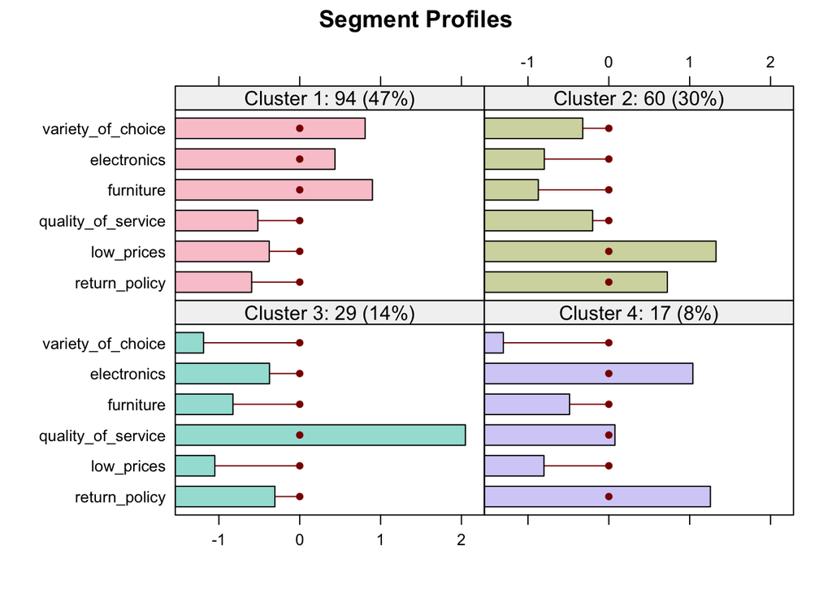

```r
# Plot segment profiles
barchart(hier_clust_flex, main = "Segment Profiles")
```

- **Cluster 1:** High variety and furniture (**Assortment Seekers**).
- **Cluster 2:** High low_prices and moderate returns (**Price-Sensitive**).
- **Cluster 3:** Very high quality_of_service (**Service Lovers**).
- **Cluster 4:** High electronics and return_policy (**Tech & Returns).**

### 2.15: Segment Naming (Unstandardized Means)

```r
# Add the cluster assignment to the un-normalized data set
retailer <- retailer %>%
  mutate(cluster4 = hc4)

# Compute the average values of the un-normalized dataset
retailer %>%
  group_by(cluster4) %>%
  summarise(
    # Store attributes (raw 1–10 ratings)
    Mean_Variety   = round(mean(variety_of_choice),   2),
    Mean_Electronics = round(mean(electronics),      2),
    Mean_Furniture   = round(mean(furniture),        2),
    Mean_Service     = round(mean(quality_of_service),2),
    Mean_Price       = round(mean(low_prices),       2),
    Mean_Returns     = round(mean(return_policy),    2),
    # Demographics
    Mean_Income      = round(mean(income),           2),
    Mean_Age         = round(mean(age),              2),
    # Cluster size & proportion
    N                = n(),
    Prop             = round(n()/nrow(retailer), 2)
  ) -> raw_profiles

raw_profiles
```

```
## # A tibble: 4 × 11
##   cluster4 Mean_Variety Mean_Electronics Mean_Furniture Mean_Service Mean_Price
##      <int>        <dbl>            <dbl>          <dbl>        <dbl>      <dbl>
## 1        1         9.19             5.3            5.4          2.33       3.84
## 2        2         6.92             2.9            1.2          3.07       8.15
## 3        3         4.94             6.47           2.12         3.71       2.76
## 4        4         5.17             3.72           1.31         8.28       2.14
## # ℹ 5 more variables: Mean_Returns <dbl>, Mean_Income <dbl>, Mean_Age <dbl>,
## #   N <int>, Prop <dbl>
```

1. **Cluster 1 (94 respondents; 47 %) – “Assortment Enthusiasts”**

Assortment Seekers captures their overriding desire for breadth of selection, which Chestnut Ridge can satisfy with its deep SKU range

**Bases:**

- **Variety_of_choice 9.19/10** (highest of all segments) and **furniture 5.40/10**: these shoppers prize an extensive product assortment above all.
- Moderate scores on electronics (5.30), price (3.84), service (2.33) and returns (3.03) indicate they’re not extreme bargain hunters or service fanatics as they simply want choice.

**Descriptors:**

- **Mean income $31.15 k**, **Mean age 31.7 yrs**: a broad, middle‐income, young-adult cohort.
- Represents the retailer’s core traffic: fairly balanced demographics and broad interests.
2. **Cluster 2 (60 respondents; 30 %) – “Bargain Hunters”**

Bargain Hunters reflects their strong price orientation and willingness to return items if not satisfied.

**Bases:**

- **Low_prices 8.15/10** (very high) and **return_policy 5.73/10**: this group is driven by bargains and expects easy returns.
- Low ratings on electronics (2.90) and furniture (1.20) show they deprioritise product breadth or premium categories.

**Descriptors:**

- **Mean income $19.05 k**, **Mean age 25.5 yrs**: younger, lower-income shoppers likely constrained by budget.
- Large size but low average spend, typical of deal-driven foot traffic.
3. **Cluster 3 (17 respondents; 9 %) – “Tech & Returns Loyalists”**

Tech & Returns Loyalists emphasize their twin priorities: cutting-edge devices plus peace-of-mind returns.

**Bases:**

- **Electronics 6.47/10** and **return_policy 6.82/10** (both highest except extremes): these are tech-savvy shoppers who count on a generous returns policy.
- Lower variety (4.94) and price sensitivity (2.76) indicate focus on electronics over décor or discounts

**Descriptors:**

- **Mean income $45.59 k**, **Mean age 38.6 yrs**: mid-career professionals with disposable income to spend on gadgets.
- Small but high-value segment, likely to purchase premium electronics.
4. **Cluster 4 (29 respondents; 14 %) – “Premium Service Seekers”**

Premium Service Seekers captures their willingness to trade up on service quality rather than chasing discounts.

**Bases:**

- **Quality_of_service 8.28/10** (by far the highest): this group demands white-glove service above price or product range.
- Moderate scores on electronics (3.72) and variety (5.17) suggest service is their defining criterion.

**Descriptors:**

- **Mean income $54.76 k**, **Mean age 46.2 yrs:** older, affluent customers who can pay extra for installation, warranties, and in-home support.
- A niche with strong lifetime-value potential through service add-ons.

These segments each convey the cluster’s dominant attitudinal base and, with the demographic descriptors, give Chestnut Ridge clear, actionable personas for targeted marketing, merchandising, and service strategies.

# 3. **Target Segment Selection**